# PA1_template

David Harter

8/10/2018

This R markdown script will create a markdown file that can be converted into HTML by knitr. The final document will include all charts and statistics required by the project description.

First, we set the global options which will determine the size of our charts and suppress warnings and messages from R.

```r
knitr::opts_chunk$set(fig.width = 12, fig.height = 12, echo = TRUE, warning = FALSE, message = FALSE)
```

```r
# Include the dplyr package for summarizing.
library(dplyr)

# Read the activity file.
activity <- read.csv("activity.csv")
```

Next, we do some prep work to get the data ready to answer the questions we must answer.

```r
# Parse dates into year/month/day for current time zone.
activity$date <- as.Date(activity$date)

# Add extra column with weekdays.
activity$weekday <- weekdays(activity$date)
```

Now we are ready to start answering the questions at hand.

## What is mean total number of steps taken per day? Plot these in a histogram. Calculate and report the mean and median of the total number of steps per day.

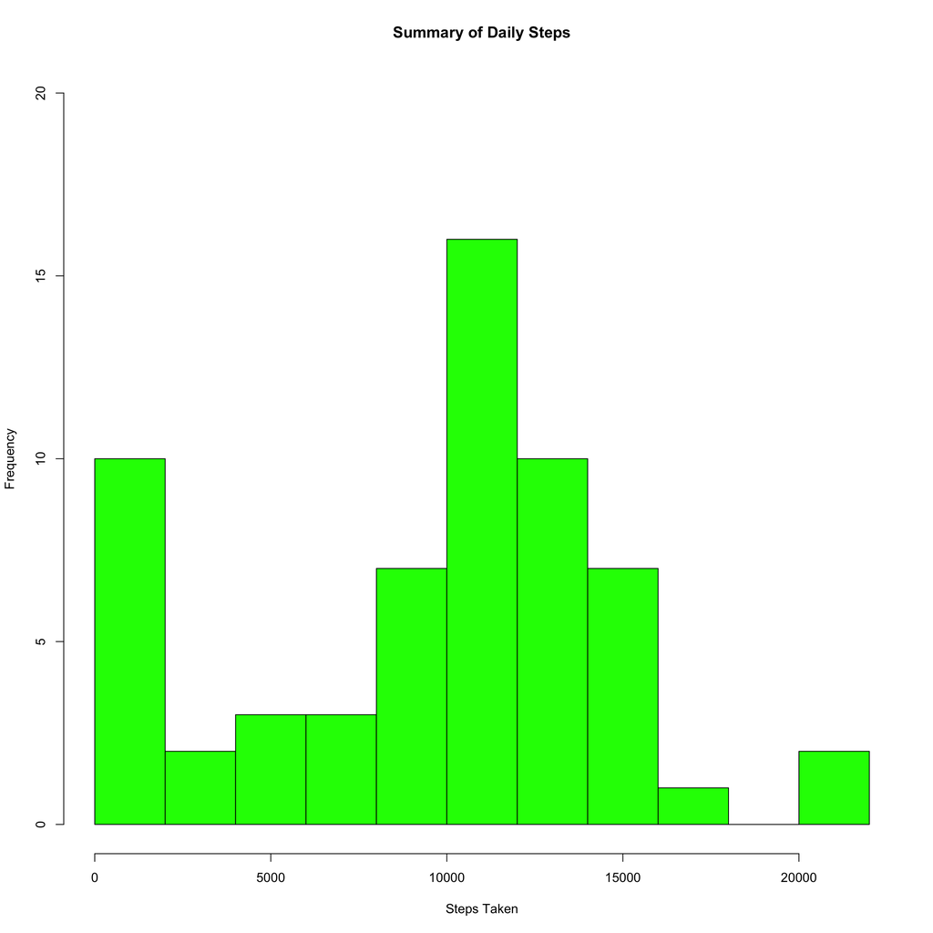

```r
# Summarize the total number of steps taken per day.
totalsteps <- summarize(group_by(activity, date), numsteps = sum(steps, na.rm = TRUE))

# Plot the histogram.
hist(totalsteps$numsteps, main = "Summary of Daily Steps", xlab = "Steps Taken", ylab = "Frequency", col = "green", ylim = c(0,20), breaks = 10)
```

Here is the mean number of steps taken per day:

```r
mean(totalsteps$numsteps)
```

```
## [1] 9354.23
```

And here is the median number of steps:

```r
median(totalsteps$numsteps)
```

```
## [1] 10395
```

## What is the average daily activity pattern?

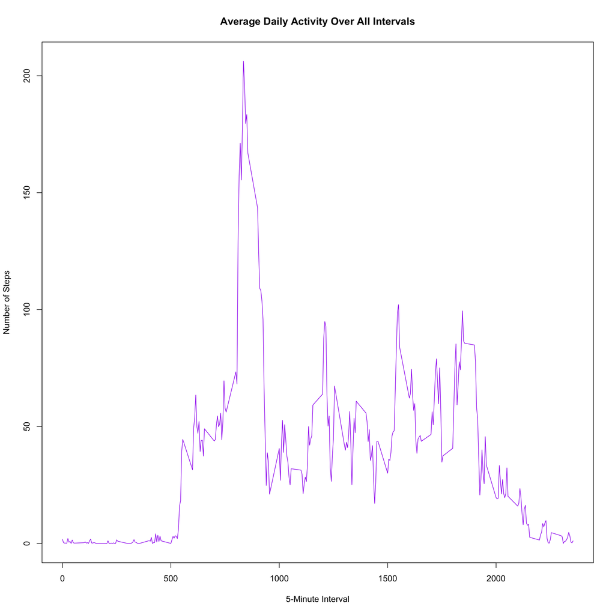

```r
# Summarize the average number of steps per interval across all days.
dailysteps <- summarize(group_by(activity, interval), avgsteps = mean(steps, na.rm = TRUE))

# Plot these intervals as a time series.
plot(dailysteps$interval, dailysteps$avgsteps, type = "l", col = "purple", main = "Average Daily Activity Over All Intervals", xlab = "5-Minute Interval", ylab = "Number of Steps")
```

## Which 5-minute interval, on average across all the days in the dataset, contains the maximum number of steps?

The interval with the maximum number of steps is:

```r
dailysteps[which.max(dailysteps$avgsteps), ]$interval
```

```
## [1] 835
```

## Imputing missing values

### Calculate and report the total number of missing values in the dataset (i.e. the total number of rows with NA).

The number of rows with NA in he step column is:

```r
sum(is.na(activity$steps))
```

```
## [1] 2304
```

### Devise a strategy for filling in all of the missing values in the dataset. The strategy does not need to be sophisticated. For example, you could use the mean/median for that day, or the mean for that 5-minute interval, etc.

In this case, I choose the mean for the 5-minute interval, since we can use data we already calculated in “dailysteps” from the previous section.

### Create a new dataset that is equal to the original dataset but with the missing data filled in.

```r
# Create vector of average steps for each interval.
impsteps <- dailysteps$avgsteps[match(activity$interval, dailysteps$interval)]

# Transform activity to impute average steps into data frame.
activity <- transform(activity, steps = ifelse(is.na(activity$steps), yes = impsteps, no = activity$steps))
```

### Make a histogram of the total number of steps taken each day

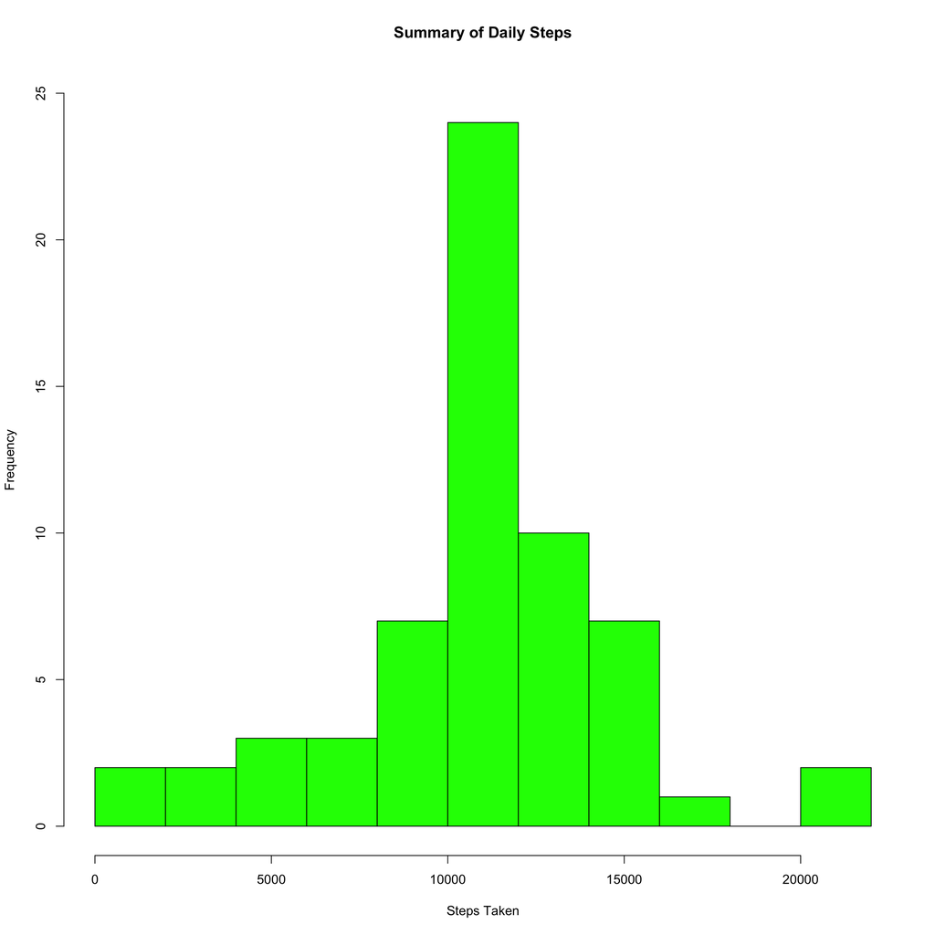

```r
# Create new group of total steps using imputed dataset.
imptotalsteps <- summarize(group_by(activity, date), numsteps = sum(steps, na.rm = TRUE))

# Plot the histogram.
hist(imptotalsteps$numsteps, main = "Summary of Daily Steps", xlab = "Steps Taken", ylab = "Frequency", col = "green", ylim = c(0,25), breaks = 10)
```

### Calculate and report the mean and median total number of steps taken per day.

Here is the mean number of steps taken per day after impution:

```r
mean(imptotalsteps$numsteps)
```

```
## [1] 10766.19
```

And here is the median number of steps after impution:

```r
median(imptotalsteps$numsteps)
```

```
## [1] 10766.19
```

### Do these values differ from the estimates from the first part of the assignment? What is the impact of imputing missing data on the estimates of the total daily number of steps?

Yes, the mean and the median of the imputed set are both higher than those of the original set, indicating that the impution process added a good deal of missing values during intervals where more steps was common. In addition, the mean and the median of the imputed set are now equal. This implies that imputing these values brought the mean closer to a true expected value.

## Are there differences in activity patterns between weekdays and weekends?

### Create a new factor variable in the dataset with two levels – “weekday” and “weekend” indicating whether a given date is a weekday or weekend day.

```r
# Create factor column with 'weekday' and 'weekend' as levels.
activity$weekpart <- factor(activity$weekday %in% c('Saturday', 'Sunday'), levels=c(TRUE, FALSE), labels=c('weekend', 'weekday'))
```

### Make a panel plot containing a time series plot (i.e. type = “l”) of the 5-minute interval (x-axis) and the average number of steps taken, averaged across all weekday days or weekend days (y-axis). See the README file in the GitHub repository to see an example of what this plot should look like using simulated data.

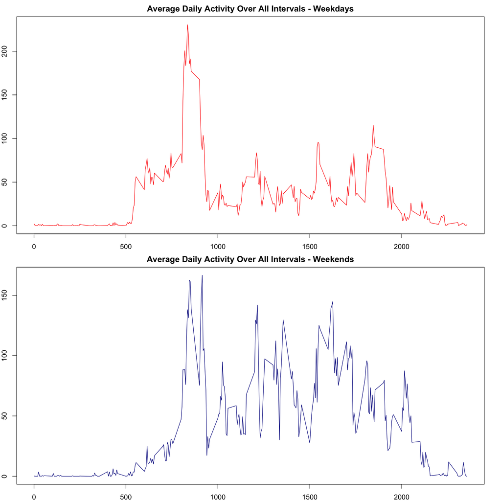

```r
# Prepare two datasets, one for each plot.
wkdaystps <- summarize(group_by(filter(activity, weekpart == "weekday"), interval), avgsteps = mean(steps))
wkendstps <- summarize(group_by(filter(activity, weekpart == "weekend"), interval), avgsteps = mean(steps))

# Prepare plotting space for two graphs, one above the other.
par(mfrow = c(2,1), mar = c(2,2,2,2))

# Plot both graphs.
plot(wkdaystps$interval, wkdaystps$avgsteps, type = "l", col = "red", main = "Average Daily Activity Over All Intervals - Weekdays", xlab = "5-Minute Interval", ylab = "Number of Steps")
plot(wkendstps$interval, wkendstps$avgsteps, type = "l", col = "dark blue", main = "Average Daily Activity Over All Intervals - Weekends", xlab = "5-Minute Interval", ylab = "Number of Steps")
```